# R Notebook

```r
library("tidyverse")
library("ggplot2")
```

# Exercício 7

Considere o mesmo modelo de geração de dados do exercício anterior. Agora, nosso objetivo é constatar o impacto do número de amostras n sobre a performance do modelo proposto pelos cientistas de dados. De forma similar ao caso anterior, utilize a instrução abaixo, em linguagem R, para a geração de um vetor com diversos valores de desvio padrão para a incerteza Gaussiana retratada pelo termo ε. Para que seja possível explorar e visualizar o impacto de n - realize, pelo menos, 1000 iterações do algoritmo. Especificamente, para cada valor do número de amostras avaliado, armazene e faça o cálculo da média aritmética sobre 1000 valores de performance, expressos pelo MSE. Um dica é aproveitar as estruturas em loop (for) do exercício anterior para a implementação das iterações. • 1) Construa o modelo de geração de dados incluindo as iterações para cada valor de n

```r
num_iter = 1000

n_vector = seq(10,100,5)

MSE_vector = rep(0,length(n_vector))
MSE        = rep(0,num_iter)



for (k in 1:length(n_vector)){

  n = n_vector[k]
  x = seq(1, 100, length.out = n)


  h_x <- 3*x + 30

  for (i in 1:num_iter){

    std = 0.5
    epsilon <- rnorm(n, 0, std)

    y <- h_x + epsilon


    h_x_estimado <- 2.8*x + 32
    MSE[i] = (1/n)*sum(((y - h_x_estimado)^2))
  }


  MSE_vector[k] = mean(MSE)
}
```

2. Faça um gráfico que mostra o impacto de n, colocado sobre o eixo x, sobre o desempenho indicado pelo MSE, apresentado no eixo y.

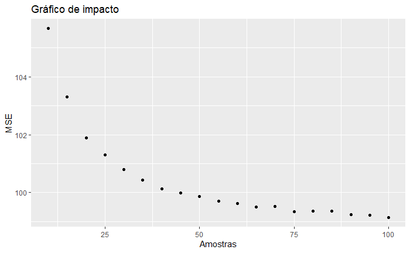

```r
df_vector <- data.frame(n_vector, MSE_vector)
df_vector %>% ggplot() +
  geom_point(aes(x = n_vector, y = MSE_vector)) +
  labs(title = "Gráfico de impacto", x = "Amostras", y = "MSE")
```